# Usando Regressão Linear para Explicar a votação de Deputados

Matheus Freitas

4 de outubro de 2018

# Sobre os dados

Esses dados foram extraídos do site do TSE, pré-processados e contemplam informações sobre aproximadamente 7.300 candidatos. A descrição de cada atributo é dada abaixo.

- sequencial_candidato: ID do candidato.
- nome: Nome do candidato.
- uf: Unidade Federativa do candidato.
- partido: Partido do candidato.
- quantidade_doacoes: Quantidade de doações que o candidato recebeu.
- quantidade_doadores: Número de doadores diferentes .
- total_receita: Soma em R$ das doações.
- media_receita: Média das doações.
- recursos_de_outros_candidatos/comites: Quantia em R$ das doações provenientes de outros candidatos ou comite partidário.
- recursos_de_pessoas_fisicas: Quantia em R$ das doações provenientes de outros CPFs.
- recursos_de_pessoas_juridicas: Quantia em R$ das doações provenientes de outros CNPJ.
- recursos_proprios: Quantia em R$ das doações provenientes do próprio candidato.
- recursos_de_partido_politico: Quantia em R$ das doações provenientes do partido político do candidato.
- votos: Se refere ao número de votos na campanha.
- quantidade_despesas: Número de despesas.
- quantidade_fornecedores: Número de fornecedores para cada despesa diferente.
- total_despesa: Soma em R$ das despesas de campanha.
- media_despesa: Média das despesas de campanha.
- cargo: Cargo ao qual é candidato.
- sexo: Sexo do candidato.
- grau: Grau de instrução do candidato.
- estado_civil: Estado civil do candidato.
- ocupacao: Ocupação do candidato.

# Visualizando os dados

Vamos, inicialmente, plotar alguns gráficos simples apenas para observar a distribuição dos dados.

## 2006

```r
melted2006 = melt(select(eleicoes2006, -ano))
```

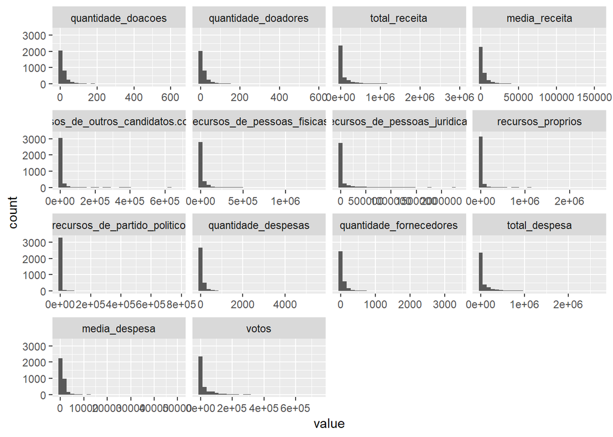

```r
ggplot(data = melted2006,
       mapping = aes(x = value)) +
  facet_wrap(~variable,
             scales = "free_x") +
  geom_histogram()
```

```r
melted2010 = melt(select(eleicoes2010, -ano))
```

[figure not shown]

```r
ggplot(data = melted2006,
       mapping = aes(x = value)) +
  facet_wrap(~variable,
             scales = "free_x") +
  geom_histogram()
```

```r
eleicoes2006$quantidade_doacoes = log(eleicoes2006$quantidade_doacoes)
eleicoes2006$quantidade_doadores = log(eleicoes2006$quantidade_doadores)
eleicoes2006$quantidade_despesas = log(eleicoes2006$quantidade_despesas)
eleicoes2006$quantidade_fornecedores = log(eleicoes2006$quantidade_fornecedores)
eleicoes2006$votos = log(eleicoes2006$votos)

eleicoes2010$quantidade_doacoes = log(eleicoes2010$quantidade_doacoes)
eleicoes2010$quantidade_doadores = log(eleicoes2010$quantidade_doadores)
eleicoes2010$quantidade_despesas = log(eleicoes2010$quantidade_despesas)
eleicoes2010$quantidade_fornecedores = log(eleicoes2010$quantidade_fornecedores)
eleicoes2010$votos = log(eleicoes2010$votos)
```